# Test 3

April 28, 2016

## Confidence Interval Estimation

### Estimation Population Mean ($\mu$)

| Variable | Description |
| --- | --- |
| $\mu$ | The population mean. |
| $\bar{x}$ | The sample mean. |
| $\sigma$ | The population standard deviation. |
| $S$ | The sample standard deviation. |
| $n$ | The sample size. |
| $\frac{Z_{\alpha}}{2}$ | $100(1-\frac{\alpha}{2})^{th}$ percentile of a $N(0, 1)$ distribution. |

- If $\sigma$ is known, then use this formula:
  - $(\bar{x}-\frac{Z_{\alpha}}{2}\frac{\sigma}{\sqrt{n}},\bar{x}+\frac{Z_{\alpha}}{2}\frac{\sigma}{\sqrt{n}})$
- If $\sigma$ is **not** known, then use this formula:
  - $(\bar{x}-\frac{t_{\alpha}(n-1)}{2}\frac{S}{\sqrt{n}},\bar{x}+\frac{t_{\alpha}(n-1)}{2}\frac{S}{\sqrt{n}})$

> What `t` value is needed as amultiplier in estimating $\mu$ with $80\%$ confidence if $\sigma$ is not known and $n=100$?

```r
z <- qnorm((1 - ((1 - 0.8) / 2)), 0 , 1) # if sigma known
t <- qt((1 - ((1 - 0.8) / 2)), (100 - 1)) # if sigma not known
z
```

```
## [1] 1.281552
```

```r
t
```

```
## [1] 1.290161
```

> What sample size $n$ is needed to estimate the mean annual household income in Boone with $99\%$ confidence and with a margin of error less that $1000? Assume that $\sigma = 5000$.

With some refactoring of the known sigma equation…

$n = (\frac{\frac{Z_{\alpha}}{2}\sigma}{MoE})^{2}$

```r
(qnorm((1 - ((1 - 0.99) / 2)), 0, 1) * 5000 / 1000) ^ 2
```

```
## [1] 165.8724
```

### Estimation Population Proportion ($P$)

$(\hat{P}-\frac{Z_{\alpha}}{2}\sqrt{\frac{\hat{P}(1-\hat{P})}{n}},\hat{P}+\frac{Z_{\alpha}}{2}\sqrt{\frac{\hat{P}(1-\hat{P})}{n}})$

> Estimate with $90\%$ confidence the proportion/percentage of all households in Boone that have kids based on a sample of $1000$ households if $320$ of these households have kids.

```r
n <- 1000
p_hat <- 320 / n
z <- qnorm((1 - ((1 - 0.9) / 2)), 0, 1)
MoE <- z * sqrt(p_hat * (1 - p_hat) / n)
lowlim <- p_hat - MoE
uplim <- p_hat + MoE
print(paste('(', lowlim, ',', uplim, ')', sep=' '))
```

```
## [1] "( 0.29573631817693 , 0.34426368182307 )"
```

We can be $90\%$ confidence that anywhere between $29.57\%$ and $34.43\%$ of all households in Boone have kids.

> What sample size $n$ is needed to estimate $P$ with $95\%$ confidence and a margin of error not overceeding $3\%$?

```r
(qnorm((1 - ((1 - 0.95) / 2)), 0, 1) / 0.03) ^ 2 * 0.25 # ballpark sample size
```

```
## [1] 1067.072
```

> What confidence level is used in a study where $\hat{P}=52\%$, $n=1022$, and the margin of error is $3\%$?

```r
z <- sqrt(0.52 * 0.48 / 1022) / 0.03
pnorm(z, 0, 1)
```

```
## [1] 0.6987907
```

Approximately $70\%$.

### Estimation Difference Betweeen 2 Means ($\mu_{1} - \mu_{2}$)

$((\bar{X_{1}}-\bar{X_{2}})-\frac{t_{\alpha}(k)}{2}\sqrt{\frac{S_{1}^{2}}{n_{1}}+\frac{S_{2}^2}{n_{2}}},(\bar{X_{1}}-\bar{X_{2}})+\frac{t_{\alpha}(k)}{2}\sqrt{\frac{S_{1}^{2}}{n_{1}}+\frac{S_{2}^2}{n_{2}}})$

| Group | Sample Size | Mean | Standard Deviation |
| --- | --- | --- | --- |
| With Sunlight | 100 | 9 | 2 |
| Without Sunlight | 50 | 6 | 3 |

> Based on the above data, estimate with $90\%$ confidence the difference in the mean number of seeds that germinate with and without sunlight.

```r
std_err <- sqrt((2 ^ 2 / 100) + (3 ^ 2 / 50))
t <- qt((1 - ((1 - 0.9) / 2)), (50 - 1))
MoE <- (t * std_err)
diff <- (9 - 6)
lowlim <- (diff - MoE)
uplim <- (diff + MoE)
print(paste('(', lowlim, ',', uplim, ')', sep=' '))
```

```
## [1] "( 2.21362792711239 , 3.78637207288761 )"
```

We can be $90\%$ confidence that the difference in the mean number of seeds that germinate with and without sunlight is anywhere from $2.21$ and $3.79$.

### Estimation Difference Between 2 Proportions ($P_{1} - P_{2}$)

$((\tilde{P_{1}}-\tilde{P_{2}}-\frac{Z_{\alpha}}{2}\sqrt{\frac{\tilde{P_{1}}(1-\tilde{P_{1}})}{\tilde{n_{1}}}+\frac{\tilde{P_{2}}(1-\tilde{P_{2}})}{\tilde{n_{2}}}}), (\tilde{P_{1}}-\tilde{P_{2}}+\frac{Z_{\alpha}}{2}\sqrt{\frac{\tilde{P_{1}}(1-\tilde{P_{1}})}{\tilde{n_{1}}}+\frac{\tilde{P_{2}}(1-\tilde{P_{2}})}{\tilde{n_{2}}}}))$

- $\tilde{n_{1}} = n_{1}+1$
- $\tilde{n_{2}} = n_{1}+1$
- $X_{1}$ = Number in first sample who have the trait of interact
- $X_{2}$ = Number in second sample who have the trait of interact

$\tilde{P_{1}}=\frac{X_{1}+1}{\tilde{n_{1}}}=\frac{X_{1}+1}{n_{1}+1}$

$\tilde{P_{2}}=\frac{X_{2}+1}{\tilde{n_{2}}}=\frac{X_{2}+1}{n_{2}+1}$

## Linear Models

### Simple Linear Regression Model (**SLRM**)

*A mathematical model for predicting a numerical response variable $y$ based on a numerical predictor variable $x$.*

$E[Y_{i}] = \alpha + \beta X_{i} + \varepsilon_{i}$

| Variable | Description |
| --- | --- |
| $E[Y_{i}]$ | expected value or mean response for the $i^{th}$ case. |
| $X_{i}$ | predictor variable value for the $i^{th}$ case. |
| $\alpha$ | y-intercept of the model. (*constant*) |
| $\beta$ | slope of the model. |
| $\varepsilon_{i}$ | random error for the $i^{th}$ case. (*unknown*) |

The mean response variable ($E[Y_{i}]$) can be determine by some deterministic component ($\alpha + \beta X_{i}$) plus some random component ($\varepsilon_{i}$).

| Variable | Description |
| --- | --- |
| $Y_{i}$ | actual y-value for the $i^{th}$ case. |
| $\hat{Y_{i}}$ | predicted y-value for the $i^{th}$ case. |
| $e_{i}=Y_{i}-\hat{Y_{i}}$ | the $i^{th}$ residual (an estimate of $\varepsilon_{i}$) |

```r
attach(mtcars)
head(mtcars)
```

```
##                    mpg cyl disp  hp drat    wt  qsec vs am gear carb
## Mazda RX4         21.0   6  160 110 3.90 2.620 16.46  0  1    4    4
## Mazda RX4 Wag     21.0   6  160 110 3.90 2.875 17.02  0  1    4    4
## Datsun 710        22.8   4  108  93 3.85 2.320 18.61  1  1    4    1
## Hornet 4 Drive    21.4   6  258 110 3.08 3.215 19.44  1  0    3    1
## Hornet Sportabout 18.7   8  360 175 3.15 3.440 17.02  0  0    3    2
## Valiant           18.1   6  225 105 2.76 3.460 20.22  1  0    3    1
```

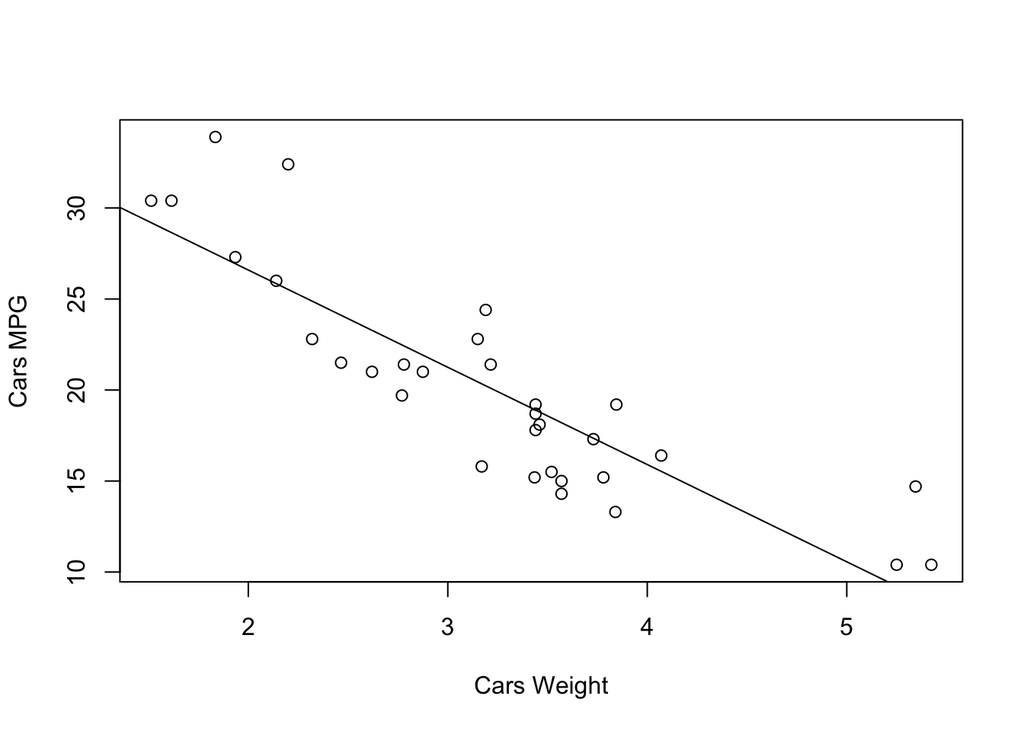

```r
plot(mtcars$wt, mtcars$mpg, xlab='Cars Weight', ylab='Cars MPG')
mod <- lm(mtcars$mpg ~ mtcars$wt)
abline(mod)
```

### Regression Diagnostics

*Methods/procedures for verifying if the assumptions behind the model are reasonably met by the data.*

Assumptions for the **SLRM**:

1. Both the $x$ and $y$ variables must be numerical.
   - Easy enough to check by hand.
2. There is a straight-line or linear relationship between $x$ and $y$.
   - Check the scatter plot of $y$ vs. $x$.
3. The error term $\varepsilon_{i}s$ are independent, normally distributed random quantities with mean $0$ and constant variance $\sigma^{2}$.
   - check the `qqnorm` plot of the residuals and perform a normality test of the residuals.
     - `qqnorm(mod$residuals)`
     - `shapiro.test(mod$residuals)`

We expect to see a *somewhat* straight line in our `qqnorm` plot if our data is truely normally distributed.

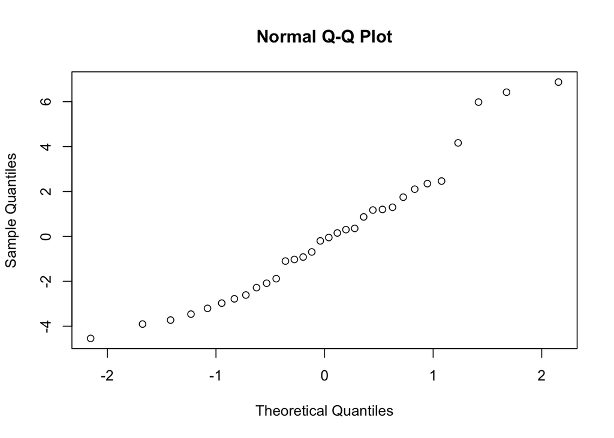

```r
qqnorm(mod$residuals)
```

The `shapiro.test` tests the $H_{o}$ that the samples came from a normal distribution. This means that if our p-value is less than or equal to $0.05$, we should reject the null hypothesis that the samples came from a normal distribution.

```r
shapiro.test(mod$residuals)
```

```
##
##  Shapiro-Wilk normality test
##
## data:  mod$residuals
## W = 0.94508, p-value = 0.1044
```

The ideal pattern for residual fitted values is an evenly distributed scatter plot as shown below.

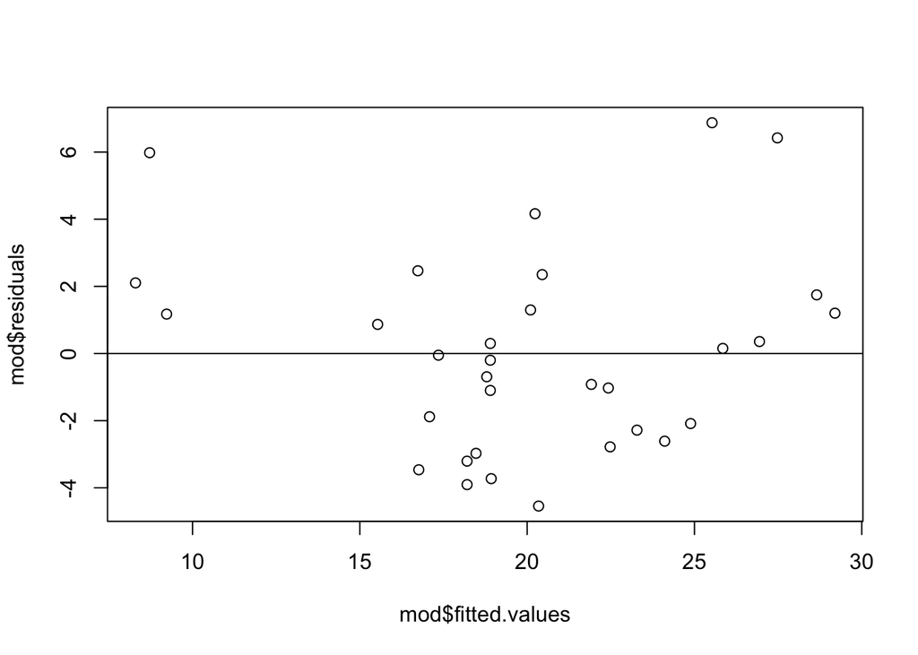

```r
plot(mod$fitted.values, mod$residuals)
abline(h=0)
```

### Hypothesis Testing for the **SLRM**

#### Hypothesis Test ($\alpha$)

In order to test $H_{o}: \alpha = \alpha_{o}$ vs. $H_{a}: \alpha \neq \alpha_{o}$, the test statistic $t = \frac{\hat{\alpha}-\alpha_{o}}{se_{\hat{\alpha}}}$ under $H_{o}$, this test statistic will have a t-distribution with $n - 2$ degress of freedom where $n$ is the sample size.

> Use the `mtcars` dataset to test if the intercept of the model relating `mpg` to `wt` is $0$ or not.

$H_{o}: \alpha = 0$ vs. $H_{a}: \alpha \neq 0$

```r
summary(mod)
```

```
##
## Call:
## lm(formula = mtcars$mpg ~ mtcars$wt)
##
## Residuals:
##     Min      1Q  Median      3Q     Max
## -4.5432 -2.3647 -0.1252  1.4096  6.8727
##
## Coefficients:
##             Estimate Std. Error t value Pr(>|t|)
## (Intercept)  37.2851     1.8776  19.858  < 2e-16 ***
## mtcars$wt    -5.3445     0.5591  -9.559 1.29e-10 ***
## ---
## Signif. codes:  0 '***' 0.001 '**' 0.01 '*' 0.05 '.' 0.1 ' ' 1
##
## Residual standard error: 3.046 on 30 degrees of freedom
## Multiple R-squared:  0.7528, Adjusted R-squared:  0.7446
## F-statistic: 91.38 on 1 and 30 DF,  p-value: 1.294e-10
```

We require a *small* p-value in order to reject the $H_{o}$.

$t = \frac{\hat{\alpha}-\alpha_{o}}{se_{\hat{\alpha}}} = \frac{37.2851 - 0}{1.8776}$

```r
((37.2851 - 0) / 1.8776)
```

```
## [1] 19.85785
```

To find the p-value for our distribution we use the following function…

```r
pt(-19.858, 30) * 2
```

```
## [1] 8.236874e-19
```

#### Hypothesis Test ($\beta$)

In order to test $H_{o}: \beta = \beta_{o}$ vs. $H_{a}: \beta \neq \beta_{o}$, the test statistic $t = \frac{\hat{\beta}-\beta_{o}}{se_{\hat{\beta}}}$ under $H_{o}$, this test statistic will have a t-distribution with $n - 2$ degrees of freedom where $n$ is the sample size.

> Use the `mtcars` dataset to test if the slope of the model relating `mpg` to `wt` is $0$ or not.

$H_{o}: \beta = 0$ vs. $H_{a}: \beta \neq 0$

```r
summary(mod)
```

```
##
## Call:
## lm(formula = mtcars$mpg ~ mtcars$wt)
##
## Residuals:
##     Min      1Q  Median      3Q     Max
## -4.5432 -2.3647 -0.1252  1.4096  6.8727
##
## Coefficients:
##             Estimate Std. Error t value Pr(>|t|)
## (Intercept)  37.2851     1.8776  19.858  < 2e-16 ***
## mtcars$wt    -5.3445     0.5591  -9.559 1.29e-10 ***
## ---
## Signif. codes:  0 '***' 0.001 '**' 0.01 '*' 0.05 '.' 0.1 ' ' 1
##
## Residual standard error: 3.046 on 30 degrees of freedom
## Multiple R-squared:  0.7528, Adjusted R-squared:  0.7446
## F-statistic: 91.38 on 1 and 30 DF,  p-value: 1.294e-10
```

$t = \frac{\hat{\beta}-\beta_{o}}{se_{\hat{\beta}}} = \frac{-5.3445 - 0}{0.5591}$

```r
((-5.3445 - 0) / 0.5591)
```

```
## [1] -9.559113
```

Use the following function to find the p-value…

```r
pt(-9.559, 30) * 2
```

```
## [1] 1.294095e-10
```

**But what happens when we have differing values for $\beta$?**

$H_{o}: \beta = -4$ vs. $H_{a}: \beta < -4$

$t = \frac{\hat{\beta}-\beta_{o}}{se_{\hat{\beta}}} = \frac{-5.3445 - (-4)}{0.5591}$

```r
((-5.3445 - (-4)) / 0.5591)
```

```
## [1] -2.404758
```

And to find the p-value…

```r
pt(-2.405, 30)
```

```
## [1] 0.01127388
```

Failing to reject the $H_{o}: \beta = 0$ means $x$ is not a statisticaly significant predictor of $y$.

### Confidence Interval Estimation for $\alpha: A100(1 - \alpha_{1})q_{0}$

$(\alpha^{2}-\frac{t_{\alpha}(n - 2)}{2}*se_{\hat{\alpha}},\alpha^{2}+\frac{t_{\alpha}(n - 2)}{2}*se_{\hat{\alpha}})$

```r
summary(mod)
```

```
##
## Call:
## lm(formula = mtcars$mpg ~ mtcars$wt)
##
## Residuals:
##     Min      1Q  Median      3Q     Max
## -4.5432 -2.3647 -0.1252  1.4096  6.8727
##
## Coefficients:
##             Estimate Std. Error t value Pr(>|t|)
## (Intercept)  37.2851     1.8776  19.858  < 2e-16 ***
## mtcars$wt    -5.3445     0.5591  -9.559 1.29e-10 ***
## ---
## Signif. codes:  0 '***' 0.001 '**' 0.01 '*' 0.05 '.' 0.1 ' ' 1
##
## Residual standard error: 3.046 on 30 degrees of freedom
## Multiple R-squared:  0.7528, Adjusted R-squared:  0.7446
## F-statistic: 91.38 on 1 and 30 DF,  p-value: 1.294e-10
```

```r
lowlim <- (37.2851 - (qt(0.95, 30) * 1.8776))
uplim <- (37.2851 + (qt(0.95, 30) * 1.8776))
print(paste('(', lowlim, ',', uplim, ')', sep=' '))
```

```
## [1] "( 34.0983229593312 , 40.4718770406688 )"
```

Therefore, we are $90\%$ confident that the *intercept* is anywhere between $34.098$ and $40.472$.

> Use the `mtcars` data to estimate with $95\%$ confidence the amount `mpg` will decrease per $1$ ton increase in `wt`.

```r
lowlim <- (-5.3445 - (qt(0.975, 30) * 0.5591))
uplim <- (-5.3445 + (qt(0.975, 30) * 0.5591))
print(paste('(', lowlim, ',', uplim, ')', sep=' '))
```

```
## [1] "( -6.48633453031802 , -4.20266546968198 )"
```

### Goodness-of-fit Measures

| Measure | Description |
| --- | --- |
| **Multiple $R^{2}$** | Proportion or percent of the variation in $y$ explained by $x$ |
| **Residual Standard Error** | Average prediction error when using the model |

```r
summary(mod)
```

```
##
## Call:
## lm(formula = mtcars$mpg ~ mtcars$wt)
##
## Residuals:
##     Min      1Q  Median      3Q     Max
## -4.5432 -2.3647 -0.1252  1.4096  6.8727
##
## Coefficients:
##             Estimate Std. Error t value Pr(>|t|)
## (Intercept)  37.2851     1.8776  19.858  < 2e-16 ***
## mtcars$wt    -5.3445     0.5591  -9.559 1.29e-10 ***
## ---
## Signif. codes:  0 '***' 0.001 '**' 0.01 '*' 0.05 '.' 0.1 ' ' 1
##
## Residual standard error: 3.046 on 30 degrees of freedom
## Multiple R-squared:  0.7528, Adjusted R-squared:  0.7446
## F-statistic: 91.38 on 1 and 30 DF,  p-value: 1.294e-10
```

We should add more predictors to our model giving us a new model called the **MLRM**.

### Multiple Linear Regression Model (**MLRM**)

*A mathematical model for the relationship between a numerical response variable and a set of predictor variables.*

$Y_{i} = \beta_{0} + \beta{1} X_{1i} + \beta_{2} X_{2i} + \cdots + \beta_{k} X_{ki} + \varepsilon_{i}$

```r
mod2 <- lm(mtcars$mpg ~ mtcars$wt + mtcars$cyl)
summary(mod2)
```

```
##
## Call:
## lm(formula = mtcars$mpg ~ mtcars$wt + mtcars$cyl)
##
## Residuals:
##     Min      1Q  Median      3Q     Max
## -4.2893 -1.5512 -0.4684  1.5743  6.1004
##
## Coefficients:
##             Estimate Std. Error t value Pr(>|t|)
## (Intercept)  39.6863     1.7150  23.141  < 2e-16 ***
## mtcars$wt    -3.1910     0.7569  -4.216 0.000222 ***
## mtcars$cyl   -1.5078     0.4147  -3.636 0.001064 **
## ---
## Signif. codes:  0 '***' 0.001 '**' 0.01 '*' 0.05 '.' 0.1 ' ' 1
##
## Residual standard error: 2.568 on 29 degrees of freedom
## Multiple R-squared:  0.8302, Adjusted R-squared:  0.8185
## F-statistic: 70.91 on 2 and 29 DF,  p-value: 6.809e-12
```

As you can see from the above summary, our Multiple $R^{2}$ percentage increased, thus our ability to predict `mpg` has improved with the addition of the predictor `cyl`.